# Jupiter_Notebook_Final_Initial_Code_Part_03

### Initial Code Report Part 03

Question #03 (Bagging/Emsenble):

What do the chances of the keyword ‘infect’ appearing inside the title column aside from the other keywords and duration?

Panda and Numpy package

```python
import pandas as pd
import numpy as np
```

Read the dataset without any abstract

```python
# read specific columns of csv file using Pandas

df = pd.read_csv("metadata_filtered_without_abstract.csv", usecols=['cord_uid', 'title', 'publish_time', 'year'])
```

Show first top ten rows of the dataset

```python
df_first_10 = df.head(10)
print(df_first_10)
```

```
   cord_uid                                              title publish_time  \
0  f9tg6xsg  Dexmedetomidine improved renal function in pat...   2020-01-02
1  f73c639r  Aortic volume determines global end-diastolic ...   2020-01-02
2  1qgpa45q  Whole genome sequencing and phylogenetic analy...   2020-01-02
3  g34f5w6b  European intensive care physicians’ experience...   2020-01-02
4  d1pd09zj  Synthetic carbohydrate-based vaccines: challen...   2020-01-03
5  grhmr3lr  Acute kidney injury in burn patients admitted ...   2020-01-02
6  44ip3jda  Identification of antigens presented by MHC fo...   2020-01-03
7  q259v3rr        Imaging of tumour response to immunotherapy   2020-01-03
8  vk7apmtg  Quantifying the relative impact of contact het...   2020-01-03
9  suao44ji  Paediatric nurses’ general self-efficacy, perc...   2020-01-03

   year
0  2020
1  2020
2  2020
3  2020
4  2020
5  2020
6  2020
7  2020
8  2020
9  2020
```

Datatype indication of the dataset

```python
# Use Dataframe.dtypes to
# give the series of
# data types as result
datatypes = df.dtypes

# Print the data types
# of each column
datatypes
```

```
cord_uid        object
title           object
publish_time    object
year             int64
dtype: object
```

Importing Sklearn package including

- The tree
- The train and test set split
- Cross validation score
- LabelEncode for preprocessing

```python
from sklearn import tree
from sklearn.model_selection import train_test_split, cross_val_score

# Importing LabelEncoder from Sklearn
# library from preprocessing Module.
from sklearn.preprocessing import LabelEncoder
```

Split the dataset into two pieces — a training set and a testing set.

```python
features = ['cord_uid','publish_time']  # X for 'cord_uid' and 'published date'
X = df.loc[:, features]
y = df.loc[:, ['title', 'year']]        # y for 'Title of the article' and 'published year of the article'
```

Consist of random sampling without replacement about 70 percent of the rows into your training set. The remaining 30 percent is put into your test set.

```python
X_train, X_test, y_train, y_test = train_test_split(X, y, random_state=0, train_size = .70)
```

Show first top ten rows of the training dataset for 'title' and the 'year'

```python
print(y_train.head(10))
```

```
                                                    title  year
235412  A Nomogram-Based Model to Predict Respiratory ...  2022
497317  Decrease of non‐classical and intermediate mon...  2020
539138  Effectiveness of BNT162b2 mRNA vaccine and ChA...  2021
498514  Efficient detection of SARS-CoV-2 RNA in the s...  2020
346152        Coronavirus as a Trigger of Graves' Disease  2021
1080    Atmospheric Plasma Supported by TiO(2) Catalys...  2020
93882   Infusion of HLA-matched and static magnetic fi...  2020
702771  COVID-19 Transmission due to Mass Mobility Bef...  2021
340940  COVID-19 pandemic severity, lockdown regimes, ...  2020
654884          Myeloid cells in sensing of tissue damage  2020
```

Filtered rows contain keyword **'patient'** inside the original Dataset and train/test dataset

```python
# Filtered keyword 'patient' inside the Dataset (df) and stored in df_patient.

df_patient = df[df['title'].str.contains('patient')]
print(len(df_patient))

print("\nModified,")

# Filtered keyword 'patient' inside the Training Dataset (y_train) and stored in df2_patient_train.

df2_patient_train = y_train[y_train['title'].str.contains('patient')]
print(len(df2_patient_train))

# Filtered keyword 'patient' inside the Testing Dataset (y_test) and stored in df2_patient_test.

df2_patient_test = y_test[y_test['title'].str.contains('patient')]
print(len(df2_patient_test))
```

```
52995

Modified,
36995
16000
```

Filtered rows contain keyword **'disease'** inside the original Dataset and train/test dataset

```python
# Filtered keyword 'lockdown' inside the Dataset (df) and stored in df_lockdown.

df_disease = df[df['title'].str.contains('disease')]
print(len(df_disease))

print("\nModified,")

# Filtered keyword 'lockdown' inside the Training Dataset (y_train) and stored in df2_lockdown_train.

df2_disease_train = y_train[y_train['title'].str.contains('disease')]
print(len(df2_disease_train))

# Filtered keyword 'lockdown' inside the Testing Dataset (y_test) and stored in df2_lockdown_test.

df2_disease_test = y_test[y_test['title'].str.contains('disease')]
print(len(df2_disease_test))
```

```
25373

Modified,
17685
7688
```

Filtered rows contain keyword **'vaccine'** inside the original Dataset and train/test dataset

```python
# Filtered keyword 'vaccine' inside the Dataset (df) and stored in df_vaccine.

df_vaccine = df[df['title'].str.contains('vaccine')]
print(len(df_vaccine))

print("\nModified,")

# Filtered keyword 'vaccine' inside the Training Dataset (y_train) and stored in df2_vaccine_train.

df2_vaccine_train = y_train[y_train['title'].str.contains('vaccine')]
print(len(df2_vaccine_train))

# Filtered keyword 'vaccine' inside the Testing Dataset (y_test) and stored in df2_vaccine_test.

df2_vaccine_test = y_test[y_test['title'].str.contains('vaccine')]
print(len(df2_vaccine_test))
```

```
11169

Modified,
7826
3343
```

Filtered rows contain keyword **'infect'** inside the original Dataset and train/test dataset

```python
# Filtered keyword 'vaccine' inside the Dataset (df) and stored in df_vaccine.

df_infact = df[df['title'].str.contains('infect')]
print(len(df_infact))

print("\nModified,")

# Filtered keyword 'vaccine' inside the Training Dataset (y_train) and stored in df2_vaccine_train.

df2_infect_train = y_train[y_train['title'].str.contains('infect')]
print(len(df2_infect_train))

# Filtered keyword 'vaccine' inside the Testing Dataset (y_test) and stored in df2_vaccine_test.

df2_infect_test = y_test[y_test['title'].str.contains('infect')]
print(len(df2_infect_test))
```

```
32274

Modified,
22487
9787
```

Split the dataset based on the year

```python
# Splited by year based on the original dataset.

# print("For Entire Dataset,")

# df_2020 = df.loc[(df['year'] == 2020)]
# print("2020",len(df_2020))

# df_2021 = df.loc[(df['year'] == 2021)]
# print("2021",len(df_2021))

# df_2022 = df.loc[(df['year'] == 2022)]
# print("2022",len(df_2022))

# print("\nFor Training Dataset,")

# Splited by year based on the training dataset

df2_2020_train = y_train.loc[(y_train['year'] == 2020)]
# print("2020",len(df2_2020_train))

df2_2021_train = y_train.loc[(y_train['year'] == 2021)]
# print("2021",len(df2_2021_train))

df2_2022_train = y_train.loc[(y_train['year'] == 2022)]
# print("2022",len(df2_2022_train))

# print("\nFor Testing Dataset,")

# Splited by year based on the testing dataset

df2_2020_test = y_test.loc[(y_test['year'] == 2020)]
# print("2020",len(df2_2020_test))

df2_2021_test = y_test.loc[(y_test['year'] == 2021)]
# print("2021",len(df2_2021_test))

df2_2022_test = y_test.loc[(y_test['year'] == 2022)]
# print("2022",len(df2_2022_test))
```

Split the dataset based on the year for keyword **'patient'**

```python
# # Splited by year based on the original dataset.

# df_patient_2020 = df_patient.loc[(df_patient['year'] == 2020)]
# print("2020",len(df_patient_2020))

# df_patient_2021= df_patient.loc[(df_patient['year'] == 2021)]
# print("2021",len(df_patient_2021))

# df_patient_2022 = df_patient.loc[(df_patient['year'] == 2022)]
# print("2022",len(df_patient_2022))

print("\nModified (Training)")

# Splited by year based on the training dataset

df2_patient_2020_train = df2_patient_train.loc[(df2_patient_train['year'] == 2020)]
print("2020",len(df2_patient_2020_train))

df2_patient_2021_train = df2_patient_train.loc[(df2_patient_train['year'] == 2021)]
print("2021",len(df2_patient_2021_train))

df2_patient_2022_train = df2_patient_train.loc[(df2_patient_train['year'] == 2022)]
print("2022",len(df2_patient_2022_train))

print("\nModified (Testing),")

# Splited by year based on the testing dataset

df2_patient_2020_test = df2_patient_test.loc[(df2_patient_test['year'] == 2020)]
print("2020",len(df2_patient_2020_test))

df2_patient_2021_test = df2_patient_test.loc[(df2_patient_test['year'] == 2021)]
print("2021",len(df2_patient_2021_test))

df2_patient_2022_test = df2_patient_test.loc[(df2_patient_test['year'] == 2022)]
print("2022",len(df2_patient_2022_test))
```

```
Modified (Training)
2020 14382
2021 18316
2022 4297

Modified (Testing),
2020 6168
2021 7854
2022 1978
```

Split the dataset based on the year for keyword **'disease'**

```python
# # Splited by year based on the original dataset.

# df_lockdown_2020 = df_lockdown.loc[(df_lockdown['year'] == 2020)]
# print("2020",len(df_lockdown_2020))

# df_lockdown_2021 = df_lockdown.loc[(df_lockdown['year'] == 2021)]
# print("2021",len(df_lockdown_2021))

# df_lockdown_2022 = df_lockdown.loc[(df_lockdown['year'] == 2022)]
# print("2022",len(df_lockdown_2022))

print("\nModified (Training),")

# Splited by year based on the training dataset

df2_disease_2020_train = df2_disease_train.loc[(df2_disease_train['year'] == 2020)]
print("2020",len(df2_disease_2020_train))

df2_disease_2021_train = df2_disease_train.loc[(df2_disease_train['year'] == 2021)]
print("2021",len(df2_disease_2021_train))

df2_disease_2022_train = df2_disease_train.loc[(df2_disease_train['year'] == 2022)]
print("2022",len(df2_disease_2022_train))

print("\nModified (Testing),")

# Splited by year based on the testing dataset

df2_disease_2020_test = df2_disease_test.loc[(df2_disease_test['year'] == 2020)]
print("2020",len(df2_disease_2020_test))

df2_disease_2021_test = df2_disease_test.loc[(df2_disease_test['year'] == 2021)]
print("2021",len(df2_disease_2021_test))

df2_disease_2022_test = df2_disease_test.loc[(df2_disease_test['year'] == 2022)]
print("2022",len(df2_disease_2022_test))
```

```
Modified (Training),
2020 8040
2021 7785
2022 1860

Modified (Testing),
2020 3401
2021 3486
2022 801
```

Split the dataset based on the year for keyword **'vaccine'**

```python
# # Splited by year based on the original dataset.

# df_vaccine_2020 = df_vaccine.loc[(df_vaccine['year'] == 2020)]
# print("2020",len(df_vaccine_2020))

# df_vaccine_2021 = df_vaccine.loc[(df_vaccine['year'] == 2021)]
# print("2021",len(df_vaccine_2021))

# df_vaccine_2022 = df_vaccine.loc[(df_vaccine['year'] == 2022)]
# print("2022",len(df_vaccine_2022))

print("\nModified (Training),")

# Splited by year based on the training dataset

df2_vaccine_2020_train = df2_vaccine_train.loc[(df2_vaccine_train['year'] == 2020)]
print("2020",len(df2_vaccine_2020_train))

df2_vaccine_2021_train = df2_vaccine_train.loc[(df2_vaccine_train['year'] == 2021)]
print("2021",len(df2_vaccine_2021_train))

df2_vaccine_2022_train = df2_vaccine_train.loc[(df2_vaccine_train['year'] == 2022)]
print("2022",len(df2_vaccine_2022_train))

print("\nModified (Testing),")

# Splited by year based on the testing dataset

df2_vaccine_2020_test = df2_vaccine_test.loc[(df2_vaccine_test['year'] == 2020)]
print("2020",len(df2_vaccine_2020_test))

df2_vaccine_2021_test = df2_vaccine_test.loc[(df2_vaccine_test['year'] == 2021)]
print("2021",len(df2_vaccine_2021_test))

df2_vaccine_2022_test = df2_vaccine_test.loc[(df2_vaccine_test['year'] == 2022)]
print("2022",len(df2_vaccine_2022_test))
```

```
Modified (Training),
2020 1380
2021 4671
2022 1775

Modified (Testing),
2020 565
2021 2016
2022 762
```

Split the dataset based on the year for keyword **'infect'**

```python
# # Splited by year based on the original dataset.

# df_vaccine_2020 = df_vaccine.loc[(df_vaccine['year'] == 2020)]
# print("2020",len(df_vaccine_2020))

# df_vaccine_2021 = df_vaccine.loc[(df_vaccine['year'] == 2021)]
# print("2021",len(df_vaccine_2021))

# df_vaccine_2022 = df_vaccine.loc[(df_vaccine['year'] == 2022)]
# print("2022",len(df_vaccine_2022))

print("\nModified (Training),")

# Splited by year based on the training dataset

df2_infect_2020_train = df2_infect_train.loc[(df2_infect_train['year'] == 2020)]
print("2020",len(df2_infect_2020_train))

df2_infect_2021_train = df2_infect_train.loc[(df2_infect_train['year'] == 2021)]
print("2021",len(df2_vaccine_2021_train))

df2_infect_2022_train = df2_infect_train.loc[(df2_infect_train['year'] == 2022)]
print("2022",len(df2_infect_2022_train))

print("\nModified (Testing),")

# Splited by year based on the testing dataset

df2_infect_2020_test = df2_infect_test.loc[(df2_infect_test['year'] == 2020)]
print("2020",len(df2_infect_2020_test))

df2_infect_2021_test = df2_infect_test.loc[(df2_infect_test['year'] == 2021)]
print("2021",len(df2_infect_2021_test))

df2_infect_2022_test = df2_infect_test.loc[(df2_infect_test['year'] == 2022)]
print("2022",len(df2_infect_2022_test))
```

```
Modified (Training),
2020 8985
2021 4671
2022 2699

Modified (Testing),
2020 3915
2021 4706
2022 1166
```

Add keyword column and combine into one.  
One with Training and one with Testing

Add keyword column for both training and testing dataset.

```python
# For training set

# Add keyword column and add 'patient' as the keyword
df2_patient_reset_train = df2_patient_train.reset_index() # Reset the index which primarily used as the id
df2_patient_reset_train['keyword'] = 'patient'            # Add column named 'keyword' and value with 'patient'
print(df2_patient_reset_train.head(5))                    # Show first five rows of new vaccine dataset

# Add keyword column and add 'disease' as the keyword
df2_disease_reset_train = df2_disease_train.reset_index() # Reset the index which primarily used as the id
df2_disease_reset_train['keyword'] = 'disease'            # Add column named 'keyword' and value with 'disease'
print(df2_disease_reset_train.head(5))                    # Show first five rows of new vaccine dataset

# Add keyword column and add 'vaccine' as the keyword
df2_vaccine_reset_train = df2_vaccine_train.reset_index() # Reset the index which primarily used as the id
df2_vaccine_reset_train['keyword'] = 'vaccine'            # Add column named 'keyword' and value with 'vaccine'
print(df2_vaccine_reset_train.head(5))                    # Show first five rows of new vaccine dataset

# Add keyword column and add 'infect' as the keyword
df2_infect_reset_train = df2_infect_train.reset_index() # Reset the index which primarily used as the id
df2_infect_reset_train['keyword'] = 'infect'            # Add column named 'keyword' and value with 'infect'
print(df2_infect_reset_train.head(5))                    # Show first five rows of new vaccine dataset
```

```
    index                                              title  year  keyword
0   93882  Infusion of HLA-matched and static magnetic fi...  2020  patient
1  637735  Effect of the COVID-19 pandemic on health insu...  2021  patient
2  341018  Effects of underlying morbidities on the occur...  2020  patient
3  506023  Corrigendum to Gathmyr D, Maruhum Bonar M, Sus...  2022  patient
4  508008  Study protocol to test the efficacy of self-ad...  2022  patient
    index                                              title  year  keyword
0  622513  Zoonotic diseases and the COVID-19 pandemic: E...  2021  disease
1  366025  Rapid SARS-CoV-2 antigen detection potentiates...  2021  disease
2  146588  The adverse impact of COVID-19 pandemic on car...  2022  disease
3  497395  Respiratory viral infections by Non-influenza ...  2020  disease
4  687776  The P2X7 receptor as a new pharmacological tar...  2022  disease
    index                                              title  year  keyword
0  539138  Effectiveness of BNT162b2 mRNA vaccine and ChA...  2021  vaccine
1  192588  Immunoinformatic approach to design a multiepi...  2021  vaccine
2  517757  Potent cross-reactive antibodies following Omi...  2022  vaccine
3  604964  Gender differences in the determinants of will...  2021  vaccine
4  726189  Recombinant Fc-fusion vaccine of RBD induced p...  2020  vaccine
    index                                              title  year keyword
0  497317  Decrease of non‐classical and intermediate mon...  2020  infect
1  637382  Intra-county modeling of COVID-19 infection wi...  2020  infect
2  279452  Development and validation of the OUTCoV score...  2021  infect
3  280352  Response to 'No evidence of SARS-CoV-2 infecti...  2020  infect
4  618320  Hospital-acquired infective endocarditis durin...  2020  infect
```

```python
# For testing set

# Add keyword column and add 'patient' as the keyword
df2_patient_reset_test = df2_patient_test.reset_index()
df2_patient_reset_test['keyword'] = 'patient'
print(df2_patient_reset_test.head(5))

# Add keyword column and add 'disease' as the keyword
df2_disease_reset_test = df2_disease_test.reset_index()
df2_disease_reset_test['keyword'] = 'disease'
print(df2_disease_reset_test.head(5))

# Add keyword column and add 'vaccine' as the keyword
df2_vaccine_reset_test = df2_vaccine_test.reset_index()
df2_vaccine_reset_test['keyword'] = 'vaccine'
print(df2_vaccine_reset_test.head(5))

# Add keyword column and add 'infect' as the keyword
df2_infect_reset_test = df2_infect_test.reset_index()
df2_infect_reset_test['keyword'] = 'infect'
print(df2_infect_reset_test.head(5))
```

```
    index                                              title  year  keyword
0  291031  Ivermectin and mortality in patients with COVI...  2021  patient
1   99107  EXPRESS: Serum biomarkers for prediction of mo...  2021  patient
2   79577  Monocyte-to-lymphocyte ratio as a prognostic f...  2020  patient
3  299001  A review of patients referred to Rheumatologyw...  2021  patient
4  676345  Association between hypertension and prognosis...  2022  patient
    index                                              title  year  keyword
0  491253  The return of the seasonal flu and cold: Other...  2022  disease
1  433876  Incidental finding of mild COVID-19 pneumonia ...  2022  disease
2  531089  Analyzing barriers for implementation of publi...  2020  disease
3  424263   Ocular manifestations of emerging viral diseases  2021  disease
4  729223  Samba, deep water, and poles: a framework for ...  2022  disease
    index                                              title  year  keyword
0  217172  Inhaled vaccine delivery in the combat against...  2021  vaccine
1  455838  CoVac501, a self-adjuvanting peptide vaccine c...  2022  vaccine
2  351325  Disentangling the effect of measures, variants...  2022  vaccine
3  544205  Parents’ and guardians’ views on the acceptabi...  2020  vaccine
4  403688  An intersectional human rights approach to pri...  2021  vaccine
    index                                              title  year keyword
0   69085  The severe acute respiratory syndrome due to c...  2020  infect
1  407446  Air pollution by NO2 and PM2.5 explains COVID-...  2020  infect
2  493232  Influence of Covid-19 infection on fetal thymu...  2021  infect
3  215625  An Emerging Innovative UV Disinfection Technol...  2021  infect
4  431485  Dizziness can be an early sole clinical manife...  2020  infect
```

```python
# For training dataset

# Combine multiple DataFrames (training set) into a single DataFrame using pd.concat.
df3_frames_train = [df2_patient_reset_train, df2_disease_reset_train, df2_vaccine_reset_train, df2_infect_reset_train]

df3_train = pd.concat(df3_frames_train)

# Output the result (first ten rows)
print(df3_train.head(10))
```

```
    index                                              title  year  keyword
0   93882  Infusion of HLA-matched and static magnetic fi...  2020  patient
1  637735  Effect of the COVID-19 pandemic on health insu...  2021  patient
2  341018  Effects of underlying morbidities on the occur...  2020  patient
3  506023  Corrigendum to Gathmyr D, Maruhum Bonar M, Sus...  2022  patient
4  508008  Study protocol to test the efficacy of self-ad...  2022  patient
5  395379  Retrospective study of low-to-moderate dose gl...  2020  patient
6  279452  Development and validation of the OUTCoV score...  2021  patient
7   59114  An advisory by the association of radiation on...  2020  patient
8  572120  Portable pocket-sized ultrasound scanner for t...  2020  patient
9  134650  Realizing early recognition of arthritis in ti...  2021  patient
```

```python
# For testing dataset

# Combine multiple DataFrames (testing set) into a single DataFrame using pd.concat.
df3_frames_test = [df2_patient_reset_test, df2_disease_reset_test, df2_vaccine_reset_test, df2_infect_reset_test]

df3_test = pd.concat(df3_frames_test)

# Output the result (first ten rows)
print(df3_test.head(10))
```

```
    index                                              title  year  keyword
0  291031  Ivermectin and mortality in patients with COVI...  2021  patient
1   99107  EXPRESS: Serum biomarkers for prediction of mo...  2021  patient
2   79577  Monocyte-to-lymphocyte ratio as a prognostic f...  2020  patient
3  299001  A review of patients referred to Rheumatologyw...  2021  patient
4  676345  Association between hypertension and prognosis...  2022  patient
5  379665  Utilization of a low-volume bowel preparation ...  2020  patient
6  664598  Challenges facing Indigenous transplant patien...  2022  patient
7  489780  Pandemic impact on patients with advanced non-...  2022  patient
8  564689  Mechanical ventilation and prone positioning i...  2021  patient
9  493781  Comparison of thrombotic events and mortality ...  2021  patient
```

Create a new dataset that contain only the 'index' as id, 'year', and the 'keyword' both training and testing set.

```python
# Create a new DataFrame (training set) by copying columns 'index', 'year', and 'keyword' to avoid modifying the original data
df5_a = df3_train[['index', 'year', 'keyword']].copy()

# Show first ten rows of the dataset
print(df5_a.head(10))
```

```
    index  year  keyword
0   93882  2020  patient
1  637735  2021  patient
2  341018  2020  patient
3  506023  2022  patient
4  508008  2022  patient
5  395379  2020  patient
6  279452  2021  patient
7   59114  2020  patient
8  572120  2020  patient
9  134650  2021  patient
```

```python
# Create a new DataFrame (testing set) by copying columns 'index', 'year', and 'keyword' to avoid modifying the original data
df5_b = df3_test[['index', 'year', 'keyword']].copy()

# Show first ten rows of the dataset
print(df5_b.head(10))
```

```
    index  year  keyword
0  291031  2021  patient
1   99107  2021  patient
2   79577  2020  patient
3  299001  2021  patient
4  676345  2022  patient
5  379665  2020  patient
6  664598  2022  patient
7  489780  2022  patient
8  564689  2021  patient
9  493781  2021  patient
```

Processing the 'year' label

For Training Set

```python
# Importing LabelEncoder from Sklearn
# library from preprocessing Module.
# from sklearn.preprocessing import LabelEncoder

# Creating a instance of label Encoder.
le_a = LabelEncoder()

# Using .fit_transform function to fit label
# encoder and return encoded label
# Encoding the year, (ex. 2020 = 0, 2021 = 1, and 2022 = 2)
label_a = le_a.fit_transform(df5_a['year'])

# printing label
label_a
```

```
array([0, 1, 0, ..., 1, 0, 1], dtype=int64)
```

```python
# removing the column 'Purchased' from df
# as it is of no use now.
df5_a.drop("year", axis=1, inplace=True)

# Appending the array to our dataFrame
# with column name 'Purchased'
df5_a["year"] = label_a

# printing Dataframe
print(df5_a.head(10))
```

```
    index  keyword  year
0   93882  patient     0
1  637735  patient     1
2  341018  patient     0
3  506023  patient     2
4  508008  patient     2
5  395379  patient     0
6  279452  patient     1
7   59114  patient     0
8  572120  patient     0
9  134650  patient     1
```

For Testing Set

```python
# Creating a instance of label Encoder.
le_b = LabelEncoder()

# Using .fit_transform function to fit label
# encoder and return encoded label
# Encoding the year, (ex. 2020 = 0, 2021 = 1, and 2022 = 2)
label_b = le_b.fit_transform(df5_b['year'])

# printing label
label_b
```

```
array([1, 1, 0, ..., 1, 1, 0], dtype=int64)
```

```python
# removing the column 'Purchased' from df
# as it is of no use now.
df5_b.drop("year", axis=1, inplace=True)

# Appending the array to our dataFrame
# with column name 'Purchased'
df5_b["year"] = label_b

# printing Dataframe
print(df5_b.head(10))
```

```
    index  keyword  year
0  291031  patient     1
1   99107  patient     1
2   79577  patient     0
3  299001  patient     1
4  676345  patient     2
5  379665  patient     0
6  664598  patient     2
7  489780  patient     2
8  564689  patient     1
9  493781  patient     1
```

Use the get_dummies method and pass the original data frame as data input using One-Hot Encoding for both training and testing set

```python
# Training Set
df5_train = pd.get_dummies(df5_a, columns=['keyword'])

print(df5_train.head(10))
```

```
    index  year  keyword_disease  keyword_infect  keyword_patient  \
0   93882     0                0               0                1
1  637735     1                0               0                1
2  341018     0                0               0                1
3  506023     2                0               0                1
4  508008     2                0               0                1
5  395379     0                0               0                1
6  279452     1                0               0                1
7   59114     0                0               0                1
8  572120     0                0               0                1
9  134650     1                0               0                1

   keyword_vaccine
0                0
1                0
2                0
3                0
4                0
5                0
6                0
7                0
8                0
9                0
```

```python
# Testing Set
df5_test = pd.get_dummies(df5_b, columns=['keyword'])

print(df5_test.head(10))
```

```
    index  year  keyword_disease  keyword_infect  keyword_patient  \
0  291031     1                0               0                1
1   99107     1                0               0                1
2   79577     0                0               0                1
3  299001     1                0               0                1
4  676345     2                0               0                1
5  379665     0                0               0                1
6  664598     2                0               0                1
7  489780     2                0               0                1
8  564689     1                0               0                1
9  493781     1                0               0                1

   keyword_vaccine
0                0
1                0
2                0
3                0
4                0
5                0
6                0
7                0
8                0
9                0
```

Use aggregation functions to performing grouped the dataset.

```python
# Training Set

# Define how to aggregate various fields
agg_functions = {'year': 'first', 'keyword_patient': 'max', 'keyword_disease': 'max', 'keyword_vaccine': 'max', 'keyword_infect': 'max'}
# When grouping data, return the first value in the 'year' column within each group.
# For the 'keyword_xx' columns, return the maximum (1) value within each group.

# Create new DataFrame by combining rows with same index values
df6_train = df5_train.groupby(df5_train['index']).aggregate(agg_functions)

# Reset the index and store in new dataframe
df6_train_reset = df6_train.reset_index()

# Copy to another Dataframe but only column with 'year' and the 'keyword_xxx'
df7_train = df6_train_reset[['year', 'keyword_patient', 'keyword_disease', 'keyword_vaccine', 'keyword_infect']].copy()

# Show first ten rows of the Dataframe
print(df7_train.head(10))
```

```
   year  keyword_patient  keyword_disease  keyword_vaccine  keyword_infect
0     0                0                0                0               1
1     0                0                0                1               0
2     0                0                0                1               0
3     0                1                0                0               0
4     0                0                1                0               0
5     0                1                0                0               0
6     0                1                0                0               0
7     0                0                0                0               1
8     0                0                0                0               1
9     0                0                0                0               1
```

```python
# Testing Set

# Define how to aggregate various fields
agg_functions = {'year': 'first', 'keyword_patient': 'max', 'keyword_disease': 'max', 'keyword_vaccine': 'max', 'keyword_infect': 'max'}
# When grouping data, return the first value in the 'year' column within each group.
# For the 'keyword_xx' columns, return the maximum (1) value within each group.

# Create new DataFrame by combining rows with same index values
df6_test = df5_test.groupby(df5_test['index']).aggregate(agg_functions)# .aggregate(agg_functions)

# Reset the index and store in new dataframe
df6_reset_test = df6_test.reset_index()

# Copy to another Dataframe but only column with 'year' and the 'keyword_xxx'
df7_test = df6_reset_test[['year', 'keyword_patient', 'keyword_disease', 'keyword_vaccine', 'keyword_infect']].copy()

# Show first ten rows of the Dataframe
print(df7_test.head(10))
```

```
   year  keyword_patient  keyword_disease  keyword_vaccine  keyword_infect
0     0                1                0                0               0
1     0                1                0                0               0
2     0                0                0                1               0
3     0                1                0                0               0
4     0                0                1                0               0
5     0                1                0                0               0
6     0                1                0                0               0
7     0                0                0                1               1
8     0                1                0                0               0
9     0                0                0                1               0
```

```python
# Modelling

# from sklearn.ensemble import RandomForestClassifier
from sklearn.metrics import accuracy_score, precision_score, recall_score # , confusion_matrix

from sklearn.metrics import classification_report

# Decision Tree Classification

from sklearn.tree import DecisionTreeClassifier # Import Decision Tree Classifier
# from sklearn import metrics # Import scikit-learn metrics module for accuracy calculation

# Use for plotting

import seaborn as sns
import matplotlib.pyplot as plt

# For begging classifier and Scaler

from sklearn.preprocessing import StandardScaler
from sklearn.pipeline import Pipeline
from sklearn.ensemble import BaggingClassifier
```

Reconfigure both X and y for the training and testing dataset.

```python
# There's no need of spliting training and testing set since the dataset is already splited in the beginning of the code for the part.

feature_cols = ['year', 'keyword_patient', 'keyword_disease', 'keyword_vaccine']
X_train2 = df7_train[feature_cols]      # Re-configured y for training dataset for 'keyword_infect'
y_train2 = df7_train.keyword_infect
X_test2 = df7_test[feature_cols]        # Re-configured y for testing dataset for 'keyword_infect'
y_test2 = df7_test.keyword_infect
```

```python
# Show first five rows for re-modified X and y training set

print("Training for x")
print(X_train2.head(5))

print("\nTraining for y")
print(y_train2.head(5))
```

```
Training for x
   year  keyword_patient  keyword_disease  keyword_vaccine
0     0                0                0                0
1     0                0                0                1
2     0                0                0                1
3     0                1                0                0
4     0                0                1                0

Training for y
0    1
1    0
2    0
3    0
4    0
Name: keyword_infect, dtype: uint8
```

Decision Tree Classification

```python
# Create Decision Tree classifer object
d_tree = DecisionTreeClassifier()
```

```python
# Train Decision Tree Classifer
d_tree = d_tree.fit(X_train2,y_train2)
```

```python
# Predict the response for test dataset
y_pred_d_tree = d_tree.predict(X_test2)
```

```python
# Model accuracy, precision and recall

accuracy_d_tree = accuracy_score(y_test2, y_pred_d_tree)
precision_d_tree = precision_score(y_test2, y_pred_d_tree)
recall_d_tree = recall_score(y_test2, y_pred_d_tree)

print("Accuracy:", accuracy_d_tree)
print("Precision:", precision_d_tree)
print("Recall:", recall_d_tree)
```

```
Accuracy: 0.9186537079283728
Precision: 1.0
Recall: 0.7340349443138857
```

```python
print(classification_report(y_test2, y_pred_d_tree))
```

```
              precision    recall  f1-score   support

           0       0.90      1.00      0.94     22212
           1       1.00      0.73      0.85      9787

    accuracy                           0.92     31999
   macro avg       0.95      0.87      0.90     31999
weighted avg       0.93      0.92      0.91     31999
```

Feature Importance

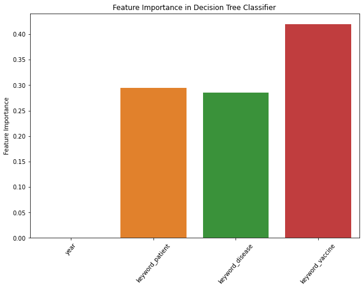

```python
# Provide insight into which features were the most important in making predictions.

# import seaborn as sns
# import matplotlib.pyplot as plt

fig = plt.figure(figsize = (10, 7))
sns.barplot(x=X_train2.columns, y=d_tree.feature_importances_)
plt.title('Feature Importance in Decision Tree Classifier')
plt.xticks(rotation = 50)
plt.ylabel('Feature Importance')
plt.show()
```

Bagging/Emsemble Modelling

Train a machine learning model

```python
# from sklearn.preprocessing import StandardScaler

scaler = StandardScaler()
X_train3 = scaler.fit_transform(X_train2)
y_train3 = y_train2.copy()
X_test3 = scaler.transform(X_test2)
y_test3 = y_test2.copy()
```

```python
# from sklearn.pipeline import Pipeline

pipeline = Pipeline([
    ('scaler', StandardScaler()),
    ('classifier', DecisionTreeClassifier(random_state=42))
])

pipeline.fit(X_train3, y_train3)
```

```
Pipeline(steps=[('scaler', StandardScaler()),
                ('classifier', DecisionTreeClassifier(random_state=42))])
```

Model evaluation

```python
# Make prediction on the testing data
y_pred_pipeline = pipeline.predict(X_test3)

# Classification Report
print(classification_report(y_pred_pipeline, y_test3))
```

```
              precision    recall  f1-score   support

           0       1.00      0.90      0.94     24815
           1       0.73      1.00      0.85      7184

    accuracy                           0.92     31999
   macro avg       0.87      0.95      0.90     31999
weighted avg       0.94      0.92      0.92     31999
```

```python
accuracy_pipeline = accuracy_score(y_test3, y_pred_pipeline)
precision_pipeline = precision_score(y_test3, y_pred_pipeline)
recall_pipeline = recall_score(y_test3, y_pred_pipeline)

print("Accuracy:", accuracy_pipeline)
print("Precision:", precision_pipeline)
print("Recall:", recall_pipeline)
```

```
Accuracy: 0.9186537079283728
Precision: 1.0
Recall: 0.7340349443138857
```

```python
# Evaluate the classifier using cross-validation
# X_train3 should be X and y_train3 should be y.
cv_scores = cross_val_score(pipeline, X_train3, y_train3, cv=5)

print(f"Cross-validation scores: {cv_scores}")
print(f"Mean CV accuracy: {np.mean(cv_scores):.2f}")
```

```
Cross-validation scores: [0.91503047 0.91400907 0.91725912 0.92294671 0.91461846]
Mean CV accuracy: 0.92
```

Bagging classifier

```python
# from sklearn.ensemble import BaggingClassifier

# Create a bagging classifier with the decision tree pipeline
bagging_classifier = BaggingClassifier(pipeline, n_estimators=10, random_state=42)

# Train the bagging classifier on the training data
bagging_classifier.fit(X_train3, y_train3)
```

```
BaggingClassifier(estimator=Pipeline(steps=[('scaler', StandardScaler()),
                                            ('classifier',
                                             DecisionTreeClassifier(random_state=42))]),
                  random_state=42)
```

```python
# Make prediction on the testing data
y_pred_bagging = bagging_classifier.predict(X_test3)

# Classification Report
print(classification_report(y_pred_bagging, y_test3))
```

```
              precision    recall  f1-score   support

           0       1.00      0.90      0.94     24815
           1       0.73      1.00      0.85      7184

    accuracy                           0.92     31999
   macro avg       0.87      0.95      0.90     31999
weighted avg       0.94      0.92      0.92     31999
```

```python
accuracy_bagging = accuracy_score(y_test3, y_pred_bagging)
precision_bagging = precision_score(y_test3, y_pred_bagging)
recall_bagging = recall_score(y_test3, y_pred_bagging)

print("Accuracy:", accuracy_bagging)
print("Precision:", precision_bagging)
print("Recall:", recall_bagging)
```

```
Accuracy: 0.9186537079283728
Precision: 1.0
Recall: 0.7340349443138857
```

```python
# Evaluate the classifier using cross-validation
# X_train3 should be X and y_train3 should be y.
cv_scores = cross_val_score(bagging_classifier, X_train3, y_train3, cv=5)

print(f"Cross-validation scores: {cv_scores}")
print(f"Mean CV accuracy: {np.mean(cv_scores):.2f}")
```

```
Cross-validation scores: [0.91503047 0.91400907 0.91725912 0.92294671 0.91461846]
Mean CV accuracy: 0.92
```